# Decision Tree Week 5

Dan Burke

11/9/2021

# Import, Prepare and Generation of First Test Model

In the following code block, the Federalist Papers data is imported. Then prepared for model generation as well as constructing both training and testing data sets. The training data set is initially comprised of all known authored papers; specifically Madison, Hamilton and Jay. Secondly, the testing data set is comprised of federalist papers which possess the “HM” and “dispt” value for their author attribute.

In an attempt to explore the data broadly, “HM” and “dispt” valued (“author” attribute) papers are included within the test data set to identify any trends of their potential predictions. Likewise Jay in included within the training data set to identify if any of the disputed papers show any tendency to Jay.

```r
#load needed libraries
library(stats)
library(dplyr)
```

```r
library(ggplot2)
library(ggfortify)
library(caret)
library(rpart)
library(rattle)
library(C50)
library(ROCR)
library(plyr)
#Data Preparation

fedpapers <- read.csv("C:\\Users\\danbu\\Desktop\\Applied Machine Learning\\Week 4\\HW4\\fedPapers85.csv")

#check for Complete Cases
sum(!complete.cases(fedpapers))
```

```
## [1] 0
```

```r
#drop the file name column
fedpapers <- fedpapers[, !names(fedpapers) %in% c("filename")]

fedpapers <- fedpapers[fedpapers$author == "Hamilton" | fedpapers$author == "Madison" | fedpapers$author == "Jay" | fedpapers$author == "dispt" |fedpapers$author == "HM" ,]

data_train <- fedpapers[fedpapers$author == "Hamilton" | fedpapers$author == "Madison" | fedpapers$author == "Jay",]
data_test <- fedpapers[fedpapers$author == "HM" | fedpapers$author == "dispt",]


sum(!complete.cases(data_train))
```

```
## [1] 0
```

```r
sum(!complete.cases(data_test))
```

```
## [1] 0
```

```r
data_train <- droplevels(data_train)
data_test <- droplevels(data_test)

dim(data_train)
```

```
## [1] 71 71
```

```r
dim(data_test)
```

```
## [1] 14 71
```

```r
papers_model <- train(author ~ ., data= data_train, metric="Accuracy", method="rpart")
print(papers_model)
```

```
## CART
##
## 71 samples
## 70 predictors
##  3 classes: 'Hamilton', 'Jay', 'Madison'
##
## No pre-processing
## Resampling: Bootstrapped (25 reps)
## Summary of sample sizes: 71, 71, 71, 71, 71, 71, ...
## Resampling results across tuning parameters:
##
##   cp   Accuracy   Kappa
##   0.0  0.8881868  0.7378944
##   0.2  0.8919448  0.7447998
##   0.7  0.7909536  0.3687440
##
## Accuracy was used to select the optimal model using the largest value.
## The final value used for the model was cp = 0.2.
```

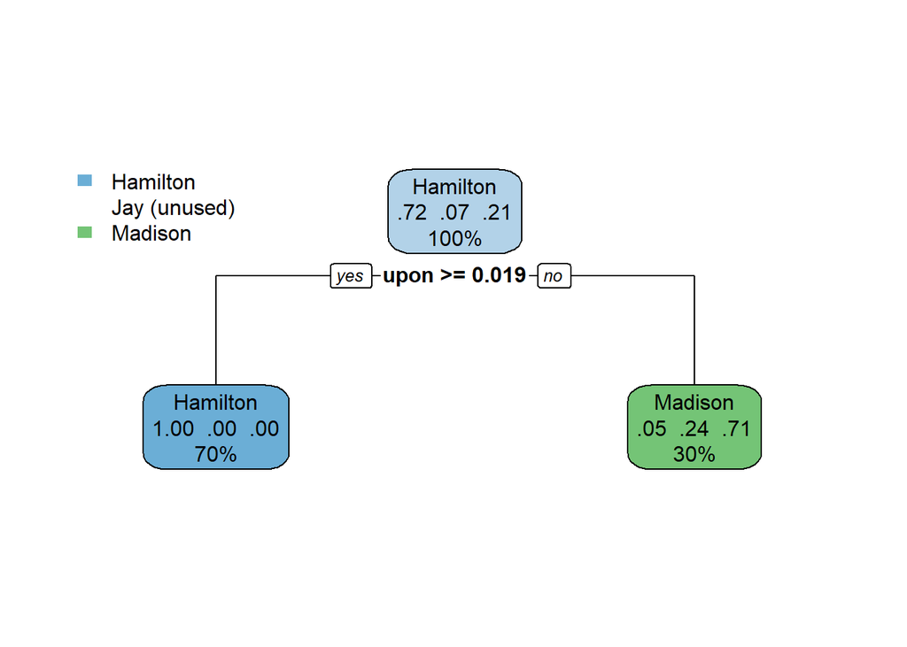

```r
library(rpart.plot)
rpart.plot(papers_model$finalModel)
```

```r
papers_predict<- predict(papers_model, newdata = data_test, na.action = na.omit, type ="prob")
print(papers_predict)
```

```
##      Hamilton       Jay   Madison
## 1  0.04761905 0.2380952 0.7142857
## 2  0.04761905 0.2380952 0.7142857
## 3  0.04761905 0.2380952 0.7142857
## 4  0.04761905 0.2380952 0.7142857
## 5  0.04761905 0.2380952 0.7142857
## 6  0.04761905 0.2380952 0.7142857
## 7  0.04761905 0.2380952 0.7142857
## 8  0.04761905 0.2380952 0.7142857
## 9  0.04761905 0.2380952 0.7142857
## 10 0.04761905 0.2380952 0.7142857
## 11 0.04761905 0.2380952 0.7142857
## 63 0.04761905 0.2380952 0.7142857
## 64 0.04761905 0.2380952 0.7142857
## 65 0.04761905 0.2380952 0.7142857
```

```r
papers_predict_raw <- predict(papers_model, newdata = data_test, na.action = na.omit, type ="raw")
print(papers_predict_raw)
```

```
##  [1] Madison Madison Madison Madison Madison Madison Madison Madison Madison
## [10] Madison Madison Madison Madison Madison
## Levels: Hamilton Jay Madison
```

# First Pass Model Tuning

```r
papers_model_prob_tuned <- train(author ~., data= data_train, method = "rpart",
                                 metric = "Accuracy",
                                 tuneLength= 8)

print(papers_model_prob_tuned$finalModel)
```

```
## n= 71
##
## node), split, n, loss, yval, (yprob)
##       * denotes terminal node
##
## 1) root 71 20 Hamilton (0.71830986 0.07042254 0.21126761)
##   2) upon>=0.019 50  0 Hamilton (1.00000000 0.00000000 0.00000000) *
##   3) upon< 0.019 21  6 Madison (0.04761905 0.23809524 0.71428571) *
```

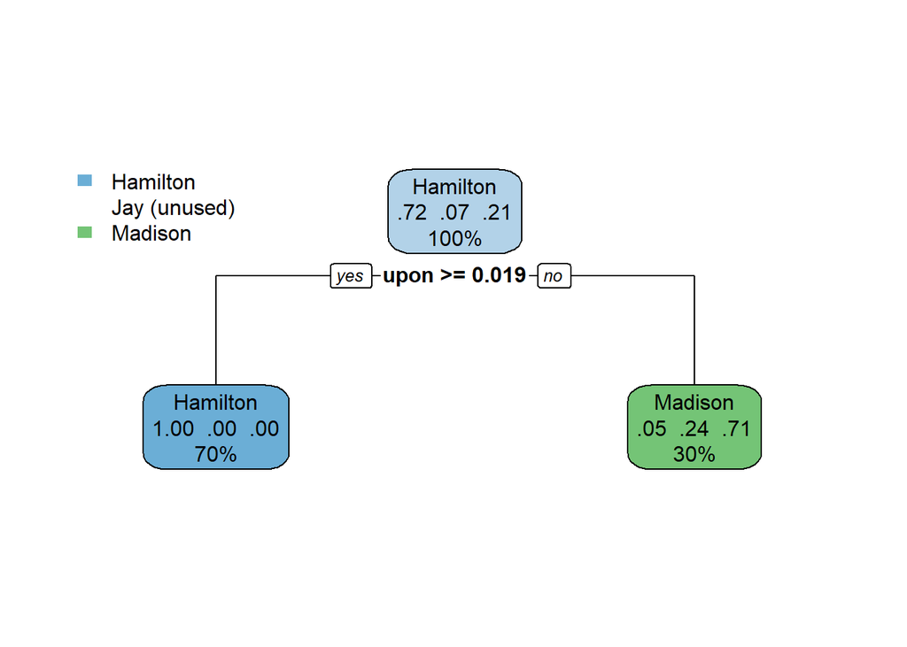

```r
rpart.plot(papers_model_prob_tuned$finalModel)
```

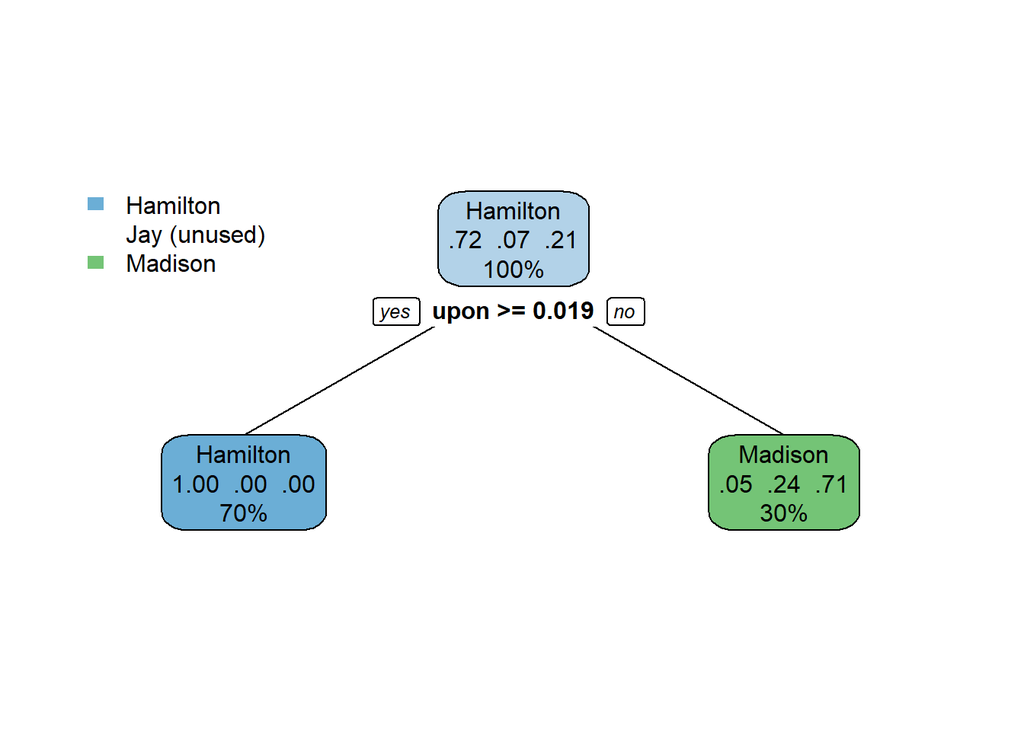

```r
rpart.plot(papers_model_prob_tuned$finalModel, fallen.leaves = FALSE)
```

```r
predict_firstPass_tuned <- predict(papers_model_prob_tuned, newdata = data_test, na.action = na.omit, type ="prob")

print(predict_firstPass_tuned)
```

```
##      Hamilton       Jay   Madison
## 1  0.04761905 0.2380952 0.7142857
## 2  0.04761905 0.2380952 0.7142857
## 3  0.04761905 0.2380952 0.7142857
## 4  0.04761905 0.2380952 0.7142857
## 5  0.04761905 0.2380952 0.7142857
## 6  0.04761905 0.2380952 0.7142857
## 7  0.04761905 0.2380952 0.7142857
## 8  0.04761905 0.2380952 0.7142857
## 9  0.04761905 0.2380952 0.7142857
## 10 0.04761905 0.2380952 0.7142857
## 11 0.04761905 0.2380952 0.7142857
## 63 0.04761905 0.2380952 0.7142857
## 64 0.04761905 0.2380952 0.7142857
## 65 0.04761905 0.2380952 0.7142857
```

# Second Pass - Decision Tree, Omission of “Jay”

Understanding the the context of the data is important. These disputed papers are thought by historians and subject matter experts to have been authored either by Hamilton or Madison. With this context in mind I generate new trees with rows which are authored by Jay, omitted.

The omission of Jay, offers similar results to the first pass, all “dispt” and “HM” author attribute examples are found to be likely authored by Madison with a probability of approximatly 94 percent.

```r
#Omit rows where Jay is believed to be the author
data_train <- fedpapers[fedpapers$author == "Hamilton" | fedpapers$author == "Madison",]
data_test <- fedpapers[fedpapers$author == "HM" | fedpapers$author == "dispt",]


sum(!complete.cases(data_train))
```

```
## [1] 0
```

```r
sum(!complete.cases(data_test))
```

```
## [1] 0
```

```r
data_train <- droplevels(data_train)
data_test <- droplevels(data_test)

dim(data_train)
```

```
## [1] 66 71
```

```r
dim(data_test)
```

```
## [1] 14 71
```

```r
papers_model <- train(author ~ ., data= data_train, metric="Accuracy", method="rpart")
print(papers_model$finalModel)
```

```
## n= 66
##
## node), split, n, loss, yval, (yprob)
##       * denotes terminal node
##
## 1) root 66 15 Hamilton (0.7727273 0.2272727)
##   2) upon>=0.019 50  0 Hamilton (1.0000000 0.0000000) *
##   3) upon< 0.019 16  1 Madison (0.0625000 0.9375000) *
```

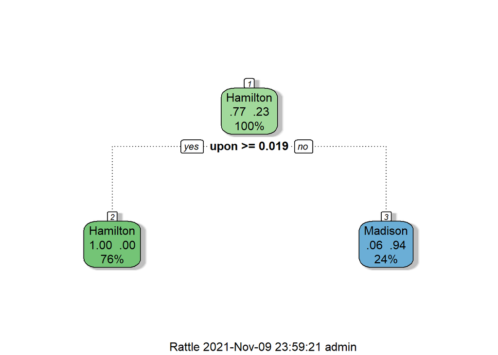

```r
fancyRpartPlot(papers_model$finalModel)
```

```r
papers_predict<- predict(papers_model, newdata = data_test, na.action = na.omit, type ="prob")
print(papers_predict)
```

```
##    Hamilton Madison
## 1    0.0625  0.9375
## 2    0.0625  0.9375
## 3    0.0625  0.9375
## 4    0.0625  0.9375
## 5    0.0625  0.9375
## 6    0.0625  0.9375
## 7    0.0625  0.9375
## 8    0.0625  0.9375
## 9    0.0625  0.9375
## 10   0.0625  0.9375
## 11   0.0625  0.9375
## 63   0.0625  0.9375
## 64   0.0625  0.9375
## 65   0.0625  0.9375
```

```r
papers_predict_raw <- predict(papers_model, newdata = data_test, na.action = na.omit, type ="raw")
print(papers_predict_raw)
```

```
##  [1] Madison Madison Madison Madison Madison Madison Madison Madison Madison
## [10] Madison Madison Madison Madison Madison
## Levels: Hamilton Madison
```

# Decision Tree Second Pass Tuning

Again with the second model, we find that the single word “upon” is the most important attribute to predict authorship by Hamilton or Madison.

We continue further with tuning and pre-pruning.

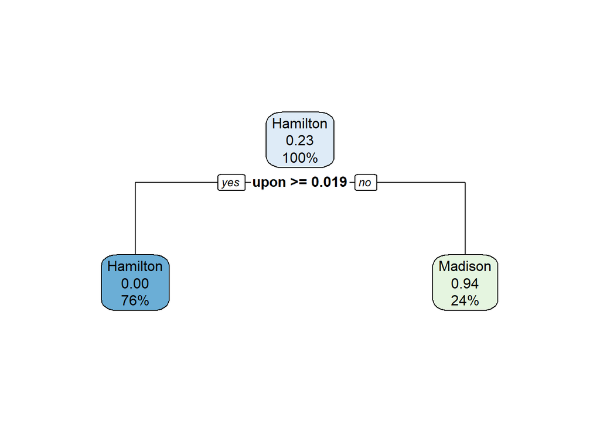

```r
data_train <- fedpapers[fedpapers$author == "Hamilton" | fedpapers$author == "Madison",]
data_test <- fedpapers[fedpapers$author == "dispt",]


ctrl <- trainControl(method = "cv", number=10)

papers_model_prob_tuned <- train(author ~., data= data_train, method = "rpart",
                                 metric = "Accuracy",
                                 tuneLength = 9)



rpart.plot(papers_model_prob_tuned$finalModel)
```

```r
print(papers_model_prob_tuned$finalModel)
```

```
## n= 66
##
## node), split, n, loss, yval, (yprob)
##       * denotes terminal node
##
## 1) root 66 15 Hamilton (0.7727273 0.2272727)
##   2) upon>=0.019 50  0 Hamilton (1.0000000 0.0000000) *
##   3) upon< 0.019 16  1 Madison (0.0625000 0.9375000) *
```

```r
#summary(papers_model_prob_tuned)
predict_secondPass_tuned <- predict(papers_model_prob_tuned, newdata = data_test, na.action = na.omit, type ="prob")

print(predict_secondPass_tuned)
```

```
##    Hamilton Madison
## 1    0.0625  0.9375
## 2    0.0625  0.9375
## 3    0.0625  0.9375
## 4    0.0625  0.9375
## 5    0.0625  0.9375
## 6    0.0625  0.9375
## 7    0.0625  0.9375
## 8    0.0625  0.9375
## 9    0.0625  0.9375
## 10   0.0625  0.9375
## 11   0.0625  0.9375
```

# Pre-pruning

In the following code block I attempt (though unsuccessful) to pre-prune the data in order to induce and observe a change in the required frequency of of "upon’. This may be due to many factors, either experimentation with hyper-parameters was not extensive enough, and or exclusion of Jay authored papers from the data set may have shortened the data set so much as to decrease complexity of the decision tree.

```r
papers_model_preprune <- train(author ~., data = data_train, method="rpart",
                               metric ="Accuracy",
                               tuneLength=8,
                               control=rpart.control(minsplit = 50, minbucket = 5, maxdepth = 8))

print(papers_model_preprune$finalModel)
```

```
## n= 66
##
## node), split, n, loss, yval, (yprob)
##       * denotes terminal node
##
## 1) root 66 15 Hamilton (0.7727273 0.2272727)
##   2) upon>=0.019 50  0 Hamilton (1.0000000 0.0000000) *
##   3) upon< 0.019 16  1 Madison (0.0625000 0.9375000) *
```

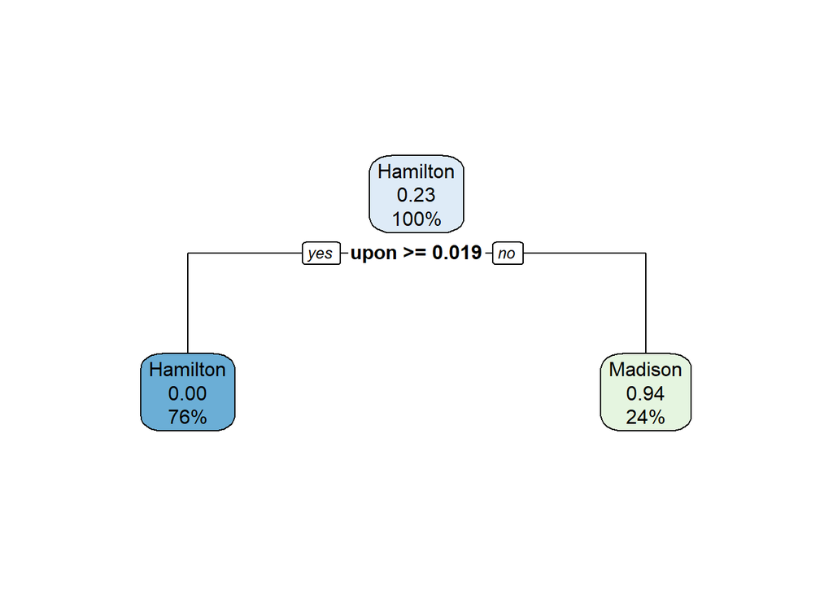

```r
#summary(papers_model_preprune$finalModel)
rpart.plot(papers_model_preprune$finalModel)
```

```r
predict_preprune <-predict(papers_model_preprune, newdata = data_test, na.action = na.omit, type ="prob")
print(predict_preprune)
```

```
##    Hamilton Madison
## 1    0.0625  0.9375
## 2    0.0625  0.9375
## 3    0.0625  0.9375
## 4    0.0625  0.9375
## 5    0.0625  0.9375
## 6    0.0625  0.9375
## 7    0.0625  0.9375
## 8    0.0625  0.9375
## 9    0.0625  0.9375
## 10   0.0625  0.9375
## 11   0.0625  0.9375
```

# Post Pruning

```r
papers_model_postprune <- prune(papers_model_prob_tuned$finalModel, cp = 0.01)
print(papers_model_postprune)
```

```
## n= 66
##
## node), split, n, loss, yval, (yprob)
##       * denotes terminal node
##
## 1) root 66 15 Hamilton (0.7727273 0.2272727)
##   2) upon>=0.019 50  0 Hamilton (1.0000000 0.0000000) *
##   3) upon< 0.019 16  1 Madison (0.0625000 0.9375000) *
```

```r
preprunepredict <- predict(papers_model_postprune, newdata = data_test, na.action = na.omit, type ="prob")
print(preprunepredict)
```

```
##    Hamilton Madison
## 1    0.0625  0.9375
## 2    0.0625  0.9375
## 3    0.0625  0.9375
## 4    0.0625  0.9375
## 5    0.0625  0.9375
## 6    0.0625  0.9375
## 7    0.0625  0.9375
## 8    0.0625  0.9375
## 9    0.0625  0.9375
## 10   0.0625  0.9375
## 11   0.0625  0.9375
```

# Conclusion

After exploring this data set and generating multiple decisions trees, both tuned, pre-pruned and post-pruned, it is most likely the authorship of disputed Federalist papers belongs to Madison; given these specific models and their outputs that. Given the opportunity to append the current data with additional data such as other works known to be both authored by Hamilton and Madison, a more comprehensive, broad and potentially, more accurate model may be generated.